# **Predicting GDP per capita**

**Introduction:**

This is an exploratory data analysis (EDA) of the Countries of the World dataset found on Kaggle at: https://www.kaggle.com/fernandol/countries-of-the-world. The goal is to better understand the dataset by exploring key relationships between variables through visualization, focusing specifically on GDP per capita. It concludes with constructing, and improving multiple linear regression models, as well as creating a random forest regression model to predict GDP per capita.

**Import libraries and read in data:**

```python
import pandas as pd
import numpy as np
import matplotlib.pyplot as plt
import seaborn as sns

from sklearn.model_selection import train_test_split, GridSearchCV
from sklearn.linear_model import LinearRegression
from sklearn.ensemble import RandomForestRegressor
from sklearn.metrics import mean_squared_error

import warnings
warnings.filterwarnings('ignore')


%cd '/Users/jonathanlynch/Desktop/DSC_423'

data = pd.read_csv('countries of the world.csv')
```

```
/Users/jonathanlynch/Desktop/DSC_423
```

## **1. Data Understanding & Preprocessing**

### **Inspect data:**

```python
# Display dataset and shape

print('Data Shape:', data.shape, '\n')
data.head()
```

```
Data Shape: (227, 20)
```

|  | Country | Region | Population | Area (sq. mi.) | Pop. Density (per sq. mi.) | Coastline (coast/area ratio) | Net migration | Infant mortality (per 1000 births) | GDP ($ per capita) | Literacy (%) | Phones (per 1000) | Arable (%) | Crops (%) | Other (%) | Climate | Birthrate | Deathrate | Agriculture | Industry | Service |
| --- | --- | --- | --- | --- | --- | --- | --- | --- | --- | --- | --- | --- | --- | --- | --- | --- | --- | --- | --- | --- |
| 0 | Afghanistan | ASIA (EX. NEAR EAST) | 31056997 | 647500 | 48,0 | 0,00 | 23,06 | 163,07 | 700.0 | 36,0 | 3,2 | 12,13 | 0,22 | 87,65 | 1 | 46,6 | 20,34 | 0,38 | 0,24 | 0,38 |
| 1 | Albania | EASTERN EUROPE | 3581655 | 28748 | 124,6 | 1,26 | -4,93 | 21,52 | 4500.0 | 86,5 | 71,2 | 21,09 | 4,42 | 74,49 | 3 | 15,11 | 5,22 | 0,232 | 0,188 | 0,579 |
| 2 | Algeria | NORTHERN AFRICA | 32930091 | 2381740 | 13,8 | 0,04 | -0,39 | 31 | 6000.0 | 70,0 | 78,1 | 3,22 | 0,25 | 96,53 | 1 | 17,14 | 4,61 | 0,101 | 0,6 | 0,298 |
| 3 | American Samoa | OCEANIA | 57794 | 199 | 290,4 | 58,29 | -20,71 | 9,27 | 8000.0 | 97,0 | 259,5 | 10 | 15 | 75 | 2 | 22,46 | 3,27 | NaN | NaN | NaN |
| 4 | Andorra | WESTERN EUROPE | 71201 | 468 | 152,1 | 0,00 | 6,6 | 4,05 | 19000.0 | 100,0 | 497,2 | 2,22 | 0 | 97,78 | 3 | 8,71 | 6,25 | NaN | NaN | NaN |

**Check data types:**

```python
data.info() # display data types
```

```
<class 'pandas.core.frame.DataFrame'>
RangeIndex: 227 entries, 0 to 226
Data columns (total 20 columns):
 #   Column                              Non-Null Count  Dtype
---  ------                              --------------  -----
 0   Country                             227 non-null    object
 1   Region                              227 non-null    object
 2   Population                          227 non-null    int64
 3   Area (sq. mi.)                      227 non-null    int64
 4   Pop. Density (per sq. mi.)          227 non-null    object
 5   Coastline (coast/area ratio)        227 non-null    object
 6   Net migration                       224 non-null    object
 7   Infant mortality (per 1000 births)  224 non-null    object
 8   GDP ($ per capita)                  226 non-null    float64
 9   Literacy (%)                        209 non-null    object
 10  Phones (per 1000)                   223 non-null    object
 11  Arable (%)                          225 non-null    object
 12  Crops (%)                           225 non-null    object
 13  Other (%)                           225 non-null    object
 14  Climate                             205 non-null    object
 15  Birthrate                           224 non-null    object
 16  Deathrate                           223 non-null    object
 17  Agriculture                         212 non-null    object
 18  Industry                            211 non-null    object
 19  Service                             212 non-null    object
dtypes: float64(1), int64(2), object(17)
memory usage: 35.6+ KB
```

There are 17 categorical variables and 3 numeric variables (including the target variable, GDP per capita). However, many of these (such as population density, coastline, net migration, infant mortality per 1000 births, literacy rate, phones per 1000 people, arable percentage, crops percentage, other percentage, birthrate, deathrate, agriculture, industry, and service) will need to be converted to the appropriate numeric data types. Climate is a categorical variable represented by numeric values currently in string format.

### **Clean data:**

**Rename columns:**

```python
data.columns = (['country', 'region', 'population', 'area', 'density', 'coastline', 'migration',
                 'infant mortality', 'gdp', 'literacy', 'phones', 'arable', 'crops', 'other',
                 'climate', 'birth rate', 'death rate', 'agriculture', 'industry', 'service'])
```

**Replace commas and change variables to correct data types:**

```python
data = data.replace(',', '.', regex = True)  # replace commas with period/decimal point

data = data.astype({'country': 'category', 'region': 'category','density': 'float', 'coastline': 'float',
                    'migration': 'float', 'infant mortality': 'float', 'gdp': 'float', 'literacy': 'float',
                    'phones': 'float', 'arable': 'float', 'crops': 'float', 'other': 'float', 'climate': 'float',
                    'birth rate': 'float', 'death rate': 'float', 'agriculture': 'float', 'industry': 'float',
                    'service': 'float'})
```

**Look for missing values:**

```python
print(data.isnull().sum())
```

```
country              0
region               0
population           0
area                 0
density              0
coastline            0
migration            3
infant mortality     3
gdp                  1
literacy            18
phones               4
arable               2
crops                2
other                2
climate             22
birth rate           3
death rate           4
agriculture         15
industry            16
service             15
dtype: int64
```

```python
for col in data.columns.values:
    if data[col].isnull().sum() == 0:
        continue
    if col == 'climate':
        estimate = data.groupby('region')['climate'].apply(lambda x: x.mode().max())
    else:
        estimate = data.groupby('region')[col].median()
    for region in data['region'].unique():
        data[col].loc[(data[col].isnull()) & (data['region'] == region)] = estimate[region]
```

**Verify missing values were replaced:**

```python
print(data.isnull().sum())
```

```
country             0
region              0
population          0
area                0
density             0
coastline           0
migration           0
infant mortality    0
gdp                 0
literacy            0
phones              0
arable              0
crops               0
other               0
climate             0
birth rate          0
death rate          0
agriculture         0
industry            0
service             0
dtype: int64
```

### **Explore Categorical Data:**

> - Climate variable not shown, as its interpretibility is limited (already converted to numeric values)

**Bar plot of region variable:**

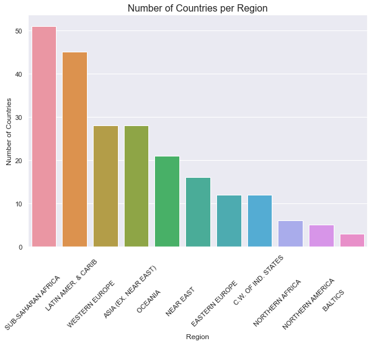

```python
region = data.region.value_counts()
regions = pd.DataFrame({'region':region.index, 'count':region.values})

plt.figure(figsize = (10,7))
sns.set(style = 'darkgrid')
sns.barplot(x = 'region', y = 'count', data = regions, order = regions.groupby('region')['count'].sum().sort_values(ascending = False).index)
plt.xticks(rotation = 45)
plt.ylabel('Number of Countries')
plt.xlabel('Region')
plt.title('Number of Countries per Region', fontsize = 16)
plt.show()
```

The above bar plot shows the number of countries that belong to each region. Clearly, Sub-Saharan Africa is the region of the world with the greatest number of countries, followed closely by Latin America and the Caribbean. The Baltics has the fewest nations.

### **Explore Numeric Data:**

**Look at the descriptive statistics for entire dataset:**

```python
data.describe()
```

|  | population | area | density | coastline | migration | infant mortality | gdp | literacy | phones | arable | crops | other | climate | birth rate | death rate | agriculture | industry | service |
| --- | --- | --- | --- | --- | --- | --- | --- | --- | --- | --- | --- | --- | --- | --- | --- | --- | --- | --- |
| count | 2.270000e+02 | 2.270000e+02 | 227.000000 | 227.000000 | 227.000000 | 227.000000 | 227.000000 | 227.000000 | 227.000000 | 227.000000 | 227.000000 | 227.000000 | 227.000000 | 227.000000 | 227.000000 | 227.000000 | 227.000000 | 227.000000 |
| mean | 2.874028e+07 | 5.982270e+05 | 379.047137 | 21.165330 | 0.035903 | 35.285463 | 9673.568282 | 83.588106 | 234.628414 | 13.783436 | 4.528040 | 81.679427 | 2.187225 | 22.060441 | 9.196652 | 0.148200 | 0.278449 | 0.570934 |
| std | 1.178913e+08 | 1.790282e+06 | 1660.185825 | 72.286863 | 4.856794 | 35.220671 | 10029.871625 | 19.315834 | 226.390263 | 12.990801 | 8.333309 | 16.079769 | 0.728050 | 11.132737 | 4.964786 | 0.143897 | 0.134792 | 0.163822 |
| min | 7.026000e+03 | 2.000000e+00 | 0.000000 | 0.000000 | -20.990000 | 2.290000 | 500.000000 | 17.600000 | 0.200000 | 0.000000 | 0.000000 | 33.330000 | 1.000000 | 7.290000 | 2.290000 | 0.000000 | 0.020000 | 0.062000 |
| 25% | 4.376240e+05 | 4.647500e+03 | 29.150000 | 0.100000 | -0.905000 | 8.215000 | 1900.000000 | 75.300000 | 38.500000 | 3.380000 | 0.190000 | 71.985000 | 2.000000 | 12.635000 | 5.795000 | 0.037000 | 0.190000 | 0.437500 |
| 50% | 4.786994e+06 | 8.660000e+04 | 78.800000 | 0.730000 | 0.000000 | 20.970000 | 5600.000000 | 92.600000 | 176.200000 | 10.420000 | 1.010000 | 85.700000 | 2.000000 | 18.790000 | 7.840000 | 0.099000 | 0.259000 | 0.580000 |
| 75% | 1.749777e+07 | 4.418110e+05 | 190.150000 | 10.345000 | 0.980000 | 55.335000 | 15700.000000 | 98.000000 | 382.900000 | 20.000000 | 4.435000 | 95.230000 | 3.000000 | 29.770000 | 10.580000 | 0.216500 | 0.338000 | 0.682000 |
| max | 1.313974e+09 | 1.707520e+07 | 16271.500000 | 870.660000 | 23.060000 | 191.190000 | 55100.000000 | 100.000000 | 1035.600000 | 62.110000 | 50.680000 | 100.000000 | 4.000000 | 50.730000 | 29.740000 | 0.769000 | 0.906000 | 0.954000 |

The above descriptive statistics show the mean, median, and standard deviations for each numeric attribute, as well as the minimum, maximum, and first quartile (Q1/25th percentile) and third quartile (Q3/75th percentile).

**Examine the descriptive statistics of Western & Eastern European regions:**

```python
data.region = data.region.str.strip() # remove spaces

western_eur = data[(data.region == 'WESTERN EUROPE')]
print('Western European Nations Statistics:\n')
print(western_eur.describe())
print()

eastern_eur = data[(data.region == 'EASTERN EUROPE')]
print('Eastern European Nations Statistics:\n')
print(eastern_eur.describe())
```

```
Western European Nations Statistics:

         population           area       density   coastline  migration  \
count  2.800000e+01      28.000000     28.000000   28.000000  28.000000
mean   1.415500e+07  132517.071429    952.042857   25.970714   3.321429
std    2.315879e+07  173940.933704   3097.797513   51.581009   2.610330
min    2.792800e+04       2.000000      2.900000    0.000000   0.000000
25%    7.438100e+04     430.000000     80.750000    0.332500   1.722500
50%    4.921096e+06   42310.000000    167.150000    2.000000   2.365000
75%    1.062642e+07  258922.500000    354.275000   19.720000   4.250000
max    8.242230e+07  547030.000000  16271.500000  205.000000  10.980000

       infant mortality           gdp   literacy       phones     arable  \
count         28.000000     28.000000   28.00000    28.000000  28.000000
mean           4.730357  27046.428571   98.50000   593.807143  16.932500
std            0.834162   7618.859745    1.78844   157.507270  13.161681
min            2.770000  17500.000000   92.80000   399.200000   0.000000
25%            4.235000  21750.000000   98.00000   462.375000   5.622500
50%            4.705000  27200.000000   99.00000   564.500000  16.910000
75%            5.277500  29700.000000   99.22500   677.225000  25.267500
max            6.240000  55100.000000  100.00000  1035.600000  54.020000

           crops       other    climate  birth rate  death rate  agriculture  \
count  28.000000   28.000000  28.000000   28.000000   28.000000    28.000000
mean    1.631429   81.412143   3.071429   10.553571    9.354643     0.042071
std     3.154769   14.499027   0.262265    1.571819    1.418986     0.055379
min     0.000000   45.790000   3.000000    8.250000    6.250000     0.005000
25%     0.000000   70.360000   3.000000    9.585000    8.470000     0.017250
50%     0.190000   82.230000   3.000000   10.325000    9.560000     0.022000
75%     0.887500   94.370000   3.000000   11.070000   10.280000     0.050000
max     9.870000  100.000000   4.000000   14.450000   12.910000     0.270000

        industry    service
count  28.000000  28.000000
mean    0.245929   0.715393
std     0.095880   0.095261
min     0.020000   0.490000
25%     0.213750   0.675250
50%     0.245000   0.720000
75%     0.295000   0.751250
```

[output cut: 28 more lines]

```
min     1.120000  47.850000   3.000000    8.770000    5.220000     0.028000
25%     1.892500  57.095000   3.000000    9.462500    9.280000     0.036500
50%     2.260000  65.335000   3.000000    9.720000   10.310000     0.081500
75%     2.982500  74.850000   3.000000   10.662500   11.552500     0.124000
max     4.420000  89.910000   4.000000   15.110000   14.270000     0.232000

        industry    service
count  12.000000  12.000000
mean    0.309250   0.598667
std     0.052448   0.040392
min     0.188000   0.549000
25%     0.301500   0.570500
50%     0.309500   0.591000
75%     0.326750   0.626500
max     0.393000   0.672000
```

The above descriptive statistics of European countries, subset by the region (Western or Eastern Europe) they belong to, show the mean, median, and standard deviations for each numeric attribute, as well as the minimum, maximum, and first quartile (Q1/25th percentile) and third quartile (Q3/75th percentile). Some of the more interesting statistics to compare by region are GDP per capita, literacy rates, infant mortality, birth rate and death rate, and the extent to which each region's economy is based on agriculture versus service. Wealthier regions tend to have higher literacy rates, lower infant mortality, lower birth rates, and a larger percentage of their economy based on services as opposed to agriculture. The distributions of many of these attributes are further explored and compared below.

**Box plot of GDP per capita by region:**

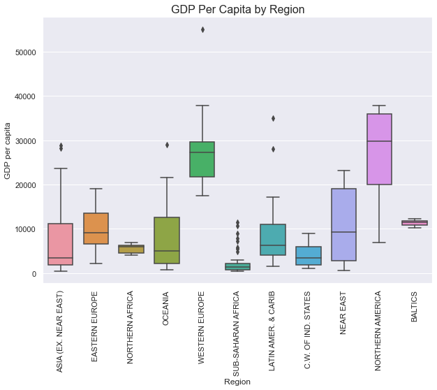

```python
plt.rcParams['figure.figsize']=(10,7)
sns.boxplot(x = 'region',y = 'gdp',data = data, width = .7)
plt.xticks(rotation = 90)
plt.ylabel('GDP per capita')
plt.xlabel('Region')
plt.title('GDP Per Capita by Region', fontsize = 16)
plt.show()
```

The above box plots illustrate visually the descriptive statistics of the variable GDP per capita, by region. The distribution of this attribute, skewness, and any outliers for each region can be evaluated from this graph. The specific GDP per capita summary statistics for Western Europe and Eastern Europe can be referenced in the previous analysis of the descriptive statistics of these regions.

**Kernal Density Estimation (KDE) of GDP per capita for Eastern European vs Western European nations:**

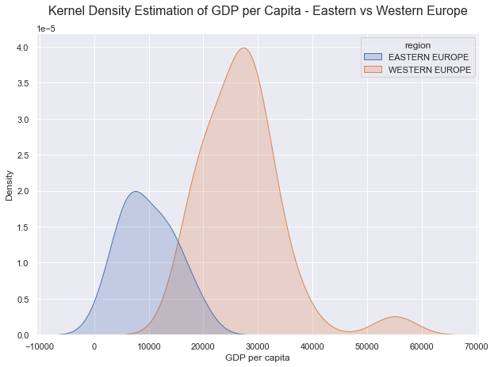

```python
frames = [eastern_eur, western_eur]
europe = pd.concat(frames)             # combine eastern and western europe

plt.figure(figsize = (10,7))
sns.kdeplot(x='gdp', hue='region', data=europe, shade=True, legend=True)
plt.xlabel('GDP per capita')
plt.title('Kernel Density Estimation of GDP per Capita - Eastern vs Western Europe\n', fontsize=16)
```

The above KDE graph compares Eastern European countries' GDP per capita to Western European countries' GDP per capita. As the above graph illustrates, Western Europe contains more countries than Eastern Europe (more observations of the variable GDP to visualize), and the vast majority of countries located in Western Europe have a higher GDP per capita than that of Eastern European nations.

**Kernal Density Estimation (KDE) of GDP per capita for Sub-Saharan African vs Northern African nations:**

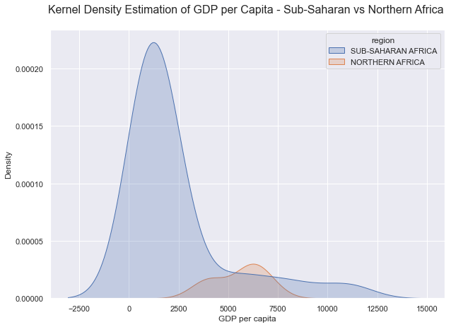

```python
africa = data[(data.region == 'SUB-SAHARAN AFRICA')]
north_africa = data[(data.region == 'NORTHERN AFRICA')]

frames2 = [africa, north_africa]
africa = pd.concat(frames2)       # combine sub-saharan africa and north africa

plt.figure(figsize = (10,7))
sns.kdeplot(x='gdp', hue='region', data=africa, shade=True, legend=True)
plt.xlabel('GDP per capita')
plt.title('Kernel Density Estimation of GDP per Capita - Sub-Saharan vs Northern Africa \n', fontsize=16)
```

The above KDE graph compares Sub-Saharan African countries' GDP per capita to Northern African nations' GDP per capita. As the above graph illustrates, Sub-Saharan Africa contains more countries than Northern Africa (more observations of the variable GDP to visualize), and most of the countries located in Sub-Saharan Africa have a lower GDP per capita than that of Northern African nations. Moreover, the GDP per capita for virtually all African countries lags far behind the GDP per capita of European nations.

**Histograms of European infant mortality, literacy, birth rates, and death rates:**

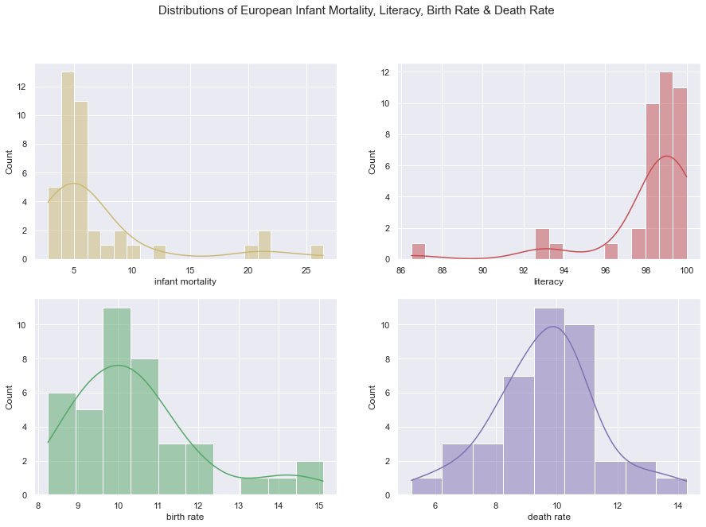

```python
fig, axes = plt.subplots(2, 2, figsize=(15, 10))
sns.set(style = 'darkgrid')
sns.histplot(europe['infant mortality'], kde = True, color = 'y', ax = axes[0, 0])
sns.histplot(europe['literacy'], kde = True, color = 'r', ax = axes[0, 1])
sns.histplot(europe['birth rate'], kde = True, color = 'g', bins = 10, ax = axes[1, 0])
sns.histplot(europe['death rate'], kde = True, color = 'm', ax = axes[1, 1])

fig.suptitle('Distributions of European Infant Mortality, Literacy, Birth Rate & Death Rate', fontsize=15)

plt.show()
```

The above histograms show the distributions of infant mortality (# per 1000 births), literacy rate, birth rate, and death rate for all European nations. Infant mortality is relatively low (mode ~ 5), and literacy is relatively high, indicating that the vast majority of European citizens are literate. Moreover, the birth rate and death rate is approximately even, indicating that the populations of countries located in Europe are remaining relatively stable. These distributions are compared against those for all African nations below, in order to illustrate key differences.

**Histograms of African infant mortality, literacy, birth rates, and death rates:**

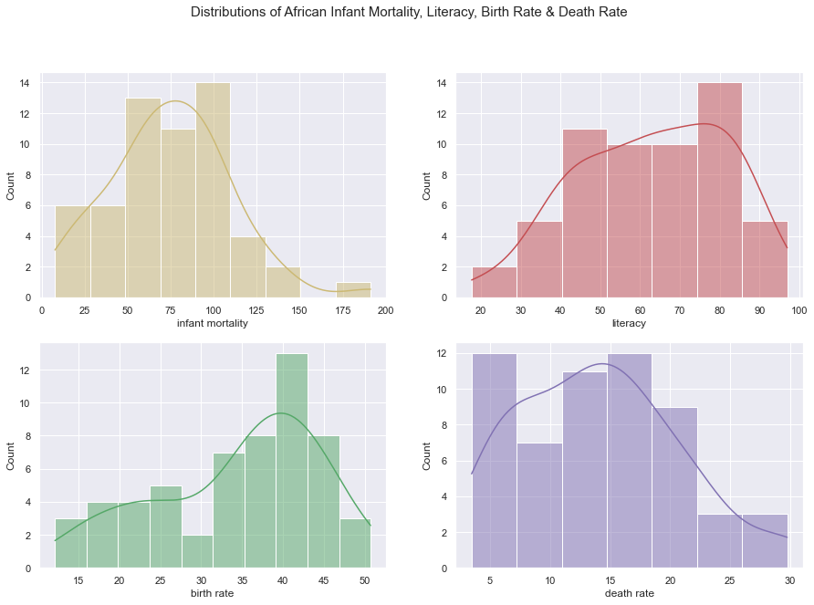

```python
fig, axes = plt.subplots(2, 2, figsize=(15, 10))
sns.set(style = 'darkgrid')
sns.histplot(africa['infant mortality'], kde = True, color = 'y', ax = axes[0, 0])
sns.histplot(africa['literacy'], kde = True, color = 'r', ax = axes[0, 1])
sns.histplot(africa['birth rate'], kde = True, color = 'g', bins = 10, ax = axes[1, 0])
sns.histplot(africa['death rate'], kde = True, color = 'm', ax = axes[1, 1])

fig.suptitle('Distributions of African Infant Mortality, Literacy, Birth Rate & Death Rate', fontsize=15)

plt.show()
```

Comparing the above distributions of all African countries to that of European nations, it is apparent that infant mortality (# per 1000 births) for African countries (mode ~ 100) is substantially higher than European nations' infant mortality (mode ~ 5). The literacy rate for African nations (mode ~ 80%) also lags far behind that of European nations (mode ~ 99%). Moreover, unlike European nations, the birth rate for African countries is clearly outpacing the death rate, indicating that the populations of many African countries may be growing.

**Correlation matrix heatmap of numerical variables:**

> - GDP per capita & phones: 0.83
> - birth rate & infant mortality: 0.84
> - other & arable: -0.86

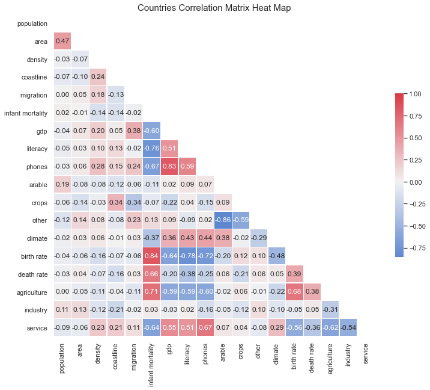

```python
sns.set(style = 'whitegrid')
fig, axes = plt.subplots(figsize=(12, 10))

# To display diagonal matrix instead of full matrix
mask = np.zeros_like(data.corr(), dtype=np.bool)
mask[np.triu_indices_from(mask)] = True

# Plot the heatmap with the mask and correct aspect ratio
cmap = sns.diverging_palette(255, 10, as_cmap=True)         #Generate a custom diverging colormap
corr_plot = sns.heatmap(data.corr(), mask=mask, cmap=cmap, vmax=1, center=0, annot=True, fmt='.2f',square=True,
                        linewidths=.5, cbar_kws={'shrink': .5}, annot_kws={'size':12})

plt.title('Countries Correlation Matrix Heat Map', fontsize=15)
plt.show()
```

The above correlation matrix heatmap shows the correlations between all numerical variables in the dataset. Most of the correlations that are going to be of greatest interest are those relating to GDP per capita. For instance, there is an 83% correlation between GDP per capita and phones (# per 1000 ppl), indicating that wealthier societies have more citizens with phones. Another point of interest/concern, is the fact that there is an 84% correlation between birth rate and infant mortality, indicating possible multicollinearity. One of these variables will most likely need to be removed (along with the variable other, which has a -86% correlation with arable) from the dataset before attempting any regression modeling.

**Scatter plots of nine variables with highest correlations (absolute value) to GDP per capita:**

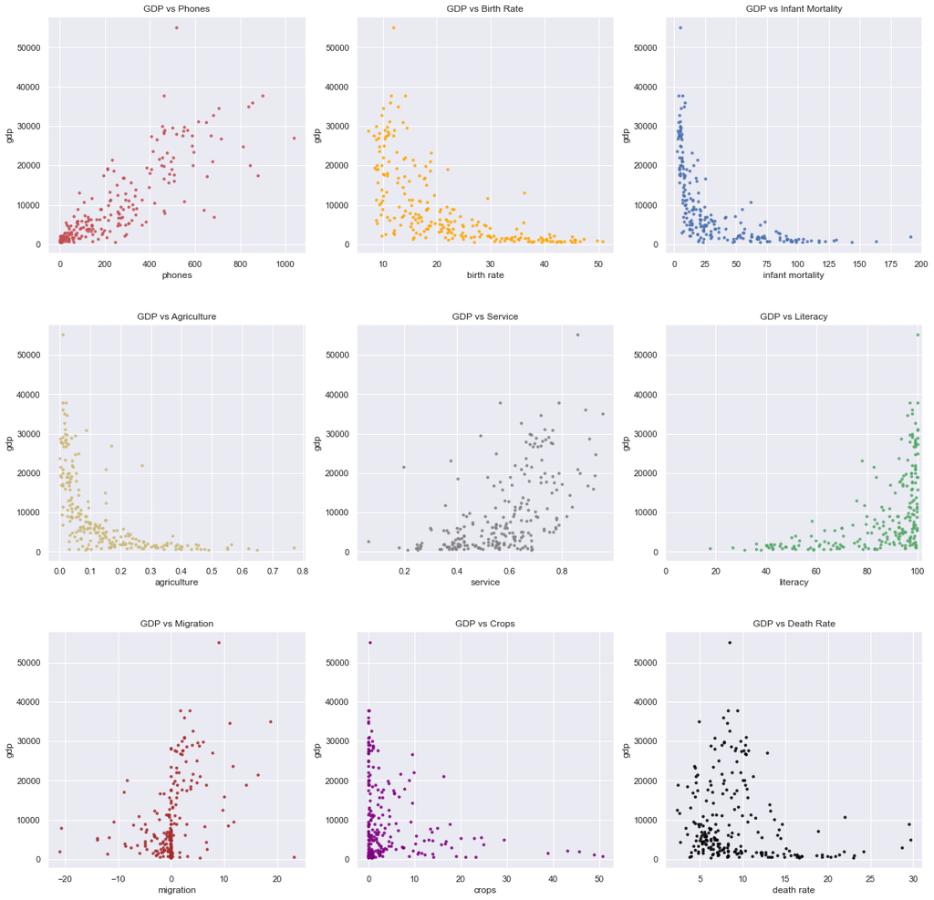

```python
sns.set(style = 'darkgrid')
fig, axes = plt.subplots(nrows = 3, ncols = 3, figsize = (20,20))
plt.subplots_adjust(hspace = 0.3, wspace = 0.2)

color = ['r','orange', 'b', 'y', 'grey', 'g', 'brown', 'purple', 'black']
header = ['GDP vs Phones', 'GDP vs Birth Rate', 'GDP vs Infant Mortality', 'GDP vs Agriculture',
          'GDP vs Service', 'GDP vs Literacy', 'GDP vs Migration', 'GDP vs Crops', 'GDP vs Death Rate']

# Determine highest correlations
gdp_corr = pd.Series()
for col in data.columns.values[2:]:
    if ((col != 'gdp') & (col != 'climate')):
        gdp_corr[col] = data['gdp'].corr(data[col])
corr_abs = gdp_corr.abs().sort_values(ascending = False)
gdp_corr = gdp_corr.loc[corr_abs.index]

count = 0
for i in range(3):
    for j in range(3):
        sns.regplot(x = gdp_corr.index.values[i*3+j], y ='gdp', data = data,
                   ax = axes[i,j], fit_reg = False, marker ='.', color = color[count])
        title = header[count]
        axes[i,j].set_title(title)
        count += 1
axes[1,2].set_xlim(0,102)
plt.show()
```

The above scatter plots visually portray the correlations between GDP per capita and the nine attributes (phones, birth rate, infant mortality, agriculture, service, literacy, migration, crops, and death rate) that displayed the highest correlations (in terms of absolute value) in the prior correlation matrix. From this, it is apparent that phones (# per 1000 ppl) has a strong, positive relationship with GDP per capita. Alternatively, there is a relatively strong, negative relationship between birth rate and GDP per capita. The relationship between the rest of the variables graphed above and GDP per capita can be interpreted in a similar manner.

## **2. Data Modeling**

**Split data into training and test sets:**

```python
# Manually encode region variable to numeric values
region_num = {'SUB-SAHARAN AFRICA': 1, 'LATIN AMER. & CARIB': 2, 'WESTERN EUROPE': 3, 'ASIA (EX. NEAR EAST)': 4,
              'OCEANIA': 5, 'NEAR EAST': 6, 'EASTERN EUROPE': 7, 'C.W. OF IND. STATES': 8, 'NORTHERN AFRICA': 9,
              'NORTHERN AMERICA': 10, 'BALTICS': 11}

data = data.replace(region_num)

# Split data into training and test sets
train, test = train_test_split(data, test_size = 0.3, shuffle = True, random_state = 40)

# Include all attributes except birth rate & other (multicollinearity concerns)
training_attributes = ['region', 'population', 'area', 'density', 'coastline', 'migration', 'infant mortality',
                       'literacy', 'phones', 'arable', 'crops', 'climate', 'death rate', 'agriculture',
                       'industry', 'service']
target = 'gdp'

train_x = train[training_attributes]
train_y = train[target]

test_x = test[training_attributes]
test_y = test[target]
```

### Linear Regression:

#### Model 1:

**Fit model with all attributes:**

```python
model = LinearRegression()
model.fit(train_x, train_y)

train_pred_y = model.predict(train_x)
test_pred_y = model.predict(test_x)

train_pred_y = pd.Series(train_pred_y.clip(0, train_pred_y.max()), index = train_y.index)
test_pred_y = pd.Series(test_pred_y.clip(0, test_pred_y.max()), index = test_y.index)
```

**Evaluate model based on root mean square error (rmse) and R-squared:**

```python
rmse_train = np.sqrt(mean_squared_error(train_pred_y, train_y))

rmse_test = np.sqrt(mean_squared_error(test_pred_y, test_y))

print('rmse train:',rmse_train)
print('rmse test:',rmse_test)

r2_train = np.round(model.score(train_x, train_y)*100,0)
r2_test = np.round(model.score(test_x, test_y)*100,0)

print('\nR-squared train:', r2_train)
print('R-squared test:', r2_test)
```

```
rmse train: 4535.670907122392
rmse test: 5902.435200805256

R-squared train: 77.0
R-squared test: 67.0
```

The first model with all attributes included is not performing very well. The root mean square error (rmse) of the test set is 5,902.4 and the R-squared value of the test set is only 67.0, meaning that this model only explains about 67% of the variability in GDP per capita.

**Look at coefficient values for the feature parameters in the first model:**

```python
data_coef = pd.DataFrame({'features': training_attributes, 'coeff': model.coef_})
data_coef = data_coef.sort_values(by = ['coeff'])
data_coef
```

|  | features | coeff |
| --- | --- | --- |
| 11 | climate | -319.533648 |
| 0 | region | -123.251813 |
| 6 | infant mortality | -97.617965 |
| 9 | arable | -55.123032 |
| 7 | literacy | -20.291862 |
| 10 | crops | -19.926491 |
| 4 | coastline | -10.511121 |
| 2 | area | -0.000109 |
| 1 | population | 0.000004 |
| 3 | density | 0.207841 |
| 8 | phones | 28.474019 |
| 12 | death rate | 330.612296 |
| 5 | migration | 404.824559 |
| 15 | service | 26571.161125 |
| 13 | agriculture | 26803.127953 |
| 14 | industry | 33100.489225 |

Based on the coefficient values for the feature parameters in the first model, some attributes, such as population, area, density, and coastline, appear to have very little impact on the determination of GDP per capita. These will be removed to improve the performance of successive models.

**Remove attributes of least importance:**

```python
# Exclude: population, area, density, coastline
training_attributes = ['region', 'migration', 'infant mortality',
                       'literacy', 'phones', 'arable', 'crops', 'climate', 'death rate', 'agriculture',
                       'industry', 'service']

train_x = train[training_attributes]
train_y = train[target]

test_x = test[training_attributes]
test_y = test[target]
```

#### Model 2:

**Fit model with reduced attributes:**

```python
model2 = LinearRegression()
model2.fit(train_x, train_y)

train_pred_y = model2.predict(train_x)
test_pred_y = model2.predict(test_x)

train_pred_y = pd.Series(train_pred_y.clip(0, train_pred_y.max()), index = train_y.index)
test_pred_y = pd.Series(test_pred_y.clip(0, test_pred_y.max()), index = test_y.index)
```

**Evaluate second model (based on rmse & R-squared):**

```python
rmse_train = np.sqrt(mean_squared_error(train_pred_y, train_y))

rmse_test = np.sqrt(mean_squared_error(test_pred_y, test_y))


print('rmse train:',rmse_train)
print('rmse test:',rmse_test)

r2_train = np.round(model2.score(train_x, train_y)*100,0)
r2_test = np.round(model2.score(test_x, test_y)*100,0)

print('\nR-squared train:', r2_train)
print('R-squared test:', r2_test)
```

```
rmse train: 4565.5438169791805
rmse test: 5819.74131818732

R-squared train: 77.0
R-squared test: 70.0
```

Removing the attributes of least importance did improve the second model slightly, with a small reduction in the root mean square error (rmse) in the test set and a slight increase in the R-squared value in the test set. The root mean square error (rmse) of the test set is now 5,819.7, and the R-squared value of the test set is 70.0, indicating that this model now explains about 70% of the variability in GDP per capita.

However, the model could be futher improved by normalizing the distribution of GDP per capita by transforming this variable to the log of GDP per capita. This will effectively give more weight to countries with lower GDP levels, and reduce the impact of outliers with extremely high economic output.

**Transform GDP per capita to the log of GDP per capita:**

```python
train_y = train_y.to_frame()
train_y['gdp'] = np.log(train_y['gdp'])
train_y = train_y['gdp']

test_y = test_y.to_frame()
test_y['gdp'] = np.log(test_y['gdp'])
test_y = test_y['gdp']
```

#### Model 3:

**Model predicting normalized GDP per capita:**

```python
model3 = LinearRegression()
model3.fit(train_x, train_y)

train_pred_y = model3.predict(train_x)
test_pred_y = model3.predict(test_x)

train_pred_y = pd.Series(train_pred_y.clip(0, train_pred_y.max()), index = train_y.index)
test_pred_y = pd.Series(test_pred_y.clip(0, test_pred_y.max()), index = test_y.index)
```

**Evaluate third model (based on rmse & R-squared):**

```python
rmse_train = np.sqrt(mean_squared_error(train_pred_y, train_y))

rmse_test = np.sqrt(mean_squared_error(test_pred_y, test_y))


print('rmse train:',rmse_train)
print('rmse test:',rmse_test)

r2_train = np.round(model3.score(train_x, train_y)*100,0)
r2_test = np.round(model3.score(test_x, test_y)*100,0)

print('\nR-squared train:', r2_train)
print('R-squared test:', r2_test)
```

```
rmse train: 0.49857662622473264
rmse test: 0.5223638744909325

R-squared train: 82.0
R-squared test: 81.0
```

Normalizing GDP per capita resulted in a dramatic reduction of the root mean square error (rmse) as well as a dramatic improvement in the R-squared value of the test set. Over 80% of the variability in the log of GDP per capita is now explained by this third model. Using the log of GDP per capita as the response variable, a random forest regression model will be constructed in order to further improve predictions.

### Random Forest Regression:

**Grid search to tune hyperparameters:**

```python
model4 = RandomForestRegressor()

# grid search parameters:
parameters = {'n_estimators': [20,40,50,70,100], 'max_depth': [8,10,12,15,17,20], 'max_features': [0.01, 0.05, 0.1, .5, .8, 1.5]}
gs = GridSearchCV(model4, parameters, verbose=1, cv=5)
```

```python
gs.fit(train_x, train_y)           # grid search on training data
```

```
Fitting 5 folds for each of 180 candidates, totalling 900 fits
```

```
GridSearchCV(cv=5, estimator=RandomForestRegressor(),
             param_grid={'max_depth': [8, 10, 12, 15, 17, 20],
                         'max_features': [0.01, 0.05, 0.1, 0.5, 0.8, 1.5],
                         'n_estimators': [20, 40, 50, 70, 100]},
             verbose=1)
```

**Grid search results:**

```python
for (i, j) in gs.best_params_.items():
    print ("The optimal value of", i, "is:", j)
print()
print("The best cross-validation score on the training data was: {}".format(gs.best_score_))
```

```
The optimal value of max_depth is: 17
The optimal value of max_features is: 0.5
The optimal value of n_estimators is: 40

The best cross-validation score on the training data was: 0.8177006522814365
```

#### Model 4:

**Random forest model with tuned hyperparameters:**

```python
model4 = RandomForestRegressor(n_estimators = 40, max_depth = 17, max_features = 0.5)
model4.fit(train_x, train_y)

train_pred_y = model4.predict(train_x)
test_pred_y = model4.predict(test_x)

train_pred_y = pd.Series(train_pred_y.clip(0, train_pred_y.max()), index=train_y.index)
test_pred_y = pd.Series(test_pred_y.clip(0, test_pred_y.max()), index=test_y.index)
```

**Evaluate fourth model (based on rmse & R-squared):**

```python
rmse_train = np.sqrt(mean_squared_error(train_pred_y, train_y))

rmse_test = np.sqrt(mean_squared_error(test_pred_y, test_y))

print('rmse train:',rmse_train)
print('rmse test:',rmse_test)

r2_train = np.round(model4.score(train_x, train_y)*100,0)
r2_test = np.round(model4.score(test_x, test_y)*100,0)

print('\nR-squared train:', r2_train)
print('R-squared test:', r2_test)
```

```
rmse train: 0.2158169712147845
rmse test: 0.4696117559802646

R-squared train: 97.0
R-squared test: 85.0
```

The random forest regression model produced the lowest root mean square error (rmse) and highest R-squared value for the test set, and is the **best model**. The R-squared value for the test set improved to 85.0, indicating that approximately 85% of the variability in the log of GDP per capita is explained by this model. Based on these metrics, this model is doing a pretty good job of predicting the normalized GDP per capita.

**Bar plot of feature importance:**

```python
# Function to plot feature importance

def feature_importance_plot(importance, names, model_type):

    feature_importance = np.array(importance)
    feature_names = np.array(names)


    data={'feature_names':feature_names,'feature_importance':feature_importance}
    feat_import_df = pd.DataFrame(data)

    feat_import_df.sort_values(by=['feature_importance'], ascending=False, inplace=True)


    plt.figure(figsize=(10,8))
    sns.barplot(x=feat_import_df['feature_importance'], y=feat_import_df['feature_names'])
    plt.title(model_type + ' Feature Importance', fontsize=15)
    plt.xlabel('Feature Importance')
    plt.ylabel('Features')
```

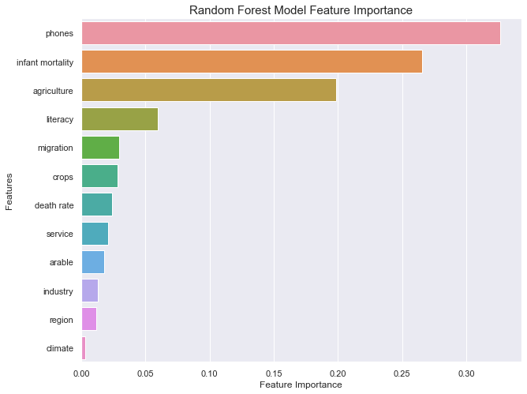

```python
feature_importance_plot(model4.feature_importances_, train_x.columns, 'Random Forest Model')
```

The above bar plot of the importance of each attribute in the random forest regression model shows that the three most significant features in predicting (normalized) GDP per capita are phones (# per 1000 ppl), followed by infant mortality (# per 1000 births), and agriculture (% of economy). Literacy rate also appears to be a somewhat important factor. However, it seems that the primary indicator of a country's economic output per person is based on the extent to which its citizens are connected via phones.